# ESS523a Final Assignment

Arian Brazenwood

2025-12-10

## Readme Introduction

This R markdown document takes ecophysiological data collected via a LICOR 600 unit at a common garden of eight common species of urban tree at the CSU spur campus and creates some exploratory data visualization figures for presenting at my PhD committee meeting I had back in September. This document essentially has three steps: Load the data, prepare the data, and generate the figures.

## Loading the Data

First we’ll load a setup script which creates a package load function and loads all packages needed by this rmarkdown document. Then we’ll bring in the data. The data has been placed in the folder of this R Project, but the file path can be replaced with wherever future data might be stored. The data is collected as two files - nighttime measurements and daytime measurements. Each tree has a unique number and identical column headers, so both of this .csv files will be read in and then row bind them to make a combined dataset.

```r
source("Setup_Script.R")

grove_day <- read_csv("data/Grove_Data_Day.csv")
grove_night <- read_csv("data/Grove_Data_Night.csv")

grove <- rbind(grove_day, grove_night)
```

## Preparing the Data

This LICOR Data set has many measurements that we don’t explicitly need and some of the instrument’s names for variables are not what these variables are referred to as in the ecophysiology literature. In this section, the code will take only the columns relevant to the figures I want to make, rename those columns to remove the instrument syntax for those column names, and then pivot them into a long form so that multiple variables can be graphed at once.

```r
grove %>%
  select(Tree_num,
         Species,
         meas_time,
         meas_loc,
         gsw,
         E_apparent,
         VPDleaf,
         PhiPS2,
         Tleaf,
         Qamb) %>%
  rename(
    Stomatal_Conductance = gsw,
    Est_Evapotranspiration = E_apparent,
    Florescence = PhiPS2,
    Light_Intensity = Qamb,
    Leaf_Temperature = Tleaf,
    Leaf_VPD = VPDleaf
  ) %>%
  pivot_longer(
    -c(Tree_num, Species, meas_time, meas_loc),
    names_to = "type",
    values_to = "value"
  ) -> grove_long
```

## Creating the Exploratory Figures

In this final section of this Rmarkdown document, we will use our cleaned and prepared data to create a suite of exploratory figures that try to tease apart the relationship between Florescence (the main response variable that is a good proxy for plant stress) by species of tree. Figures for subtotal conductance and Est_Evapotransipiration will be generated as well as these are strong co-variates with the primary response variable. Leaf Temperature and Vapor pressure deficit will also be graphed by species to understand if there are some general patterns between these species or not.

All measurements collected during the hottest week of the year. The third week of July should capture the most amount of heat stress associated with these plants, so any species related differences in vigor should be observable from this data set. All these trees have been given the same irrigation in the preceding four months and these trees are all within the same ~100m^2 field, so they should all be experiencing the same climactic conditions as well. These trees are all roughly the same size/age as well, so species based differences should really be the only driver for observable differences in the primary and secondary response variables.

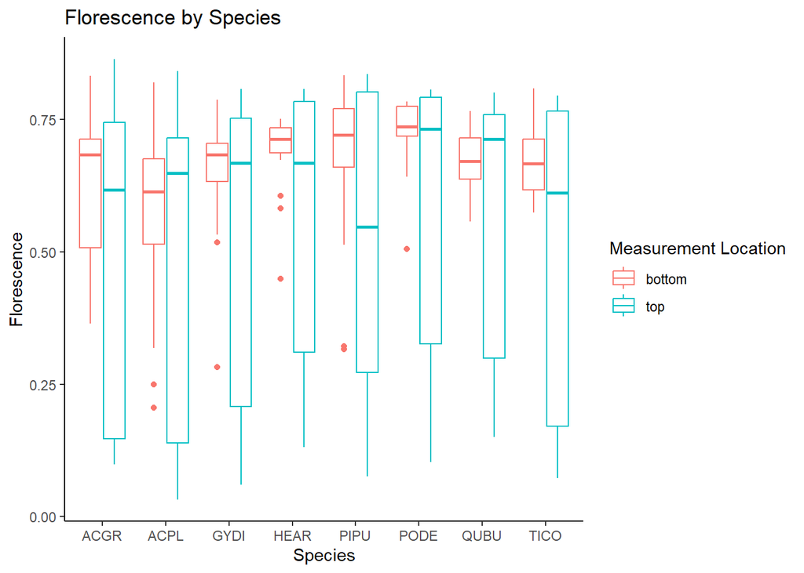

```r
#Boxplot of Florescence by Species comparing top of leaf and bottom of leaf measurements.
grove_long %>%
  filter(type == "Florescence") %>%
  ggplot() +
  geom_boxplot(aes(x = Species, y = value, color = meas_loc)) +
  theme_classic() +
  labs(
    title = "Florescence by Species",
    x = "Species",
    y = "Florescence",
    color = "Measurement Location"
  )
```

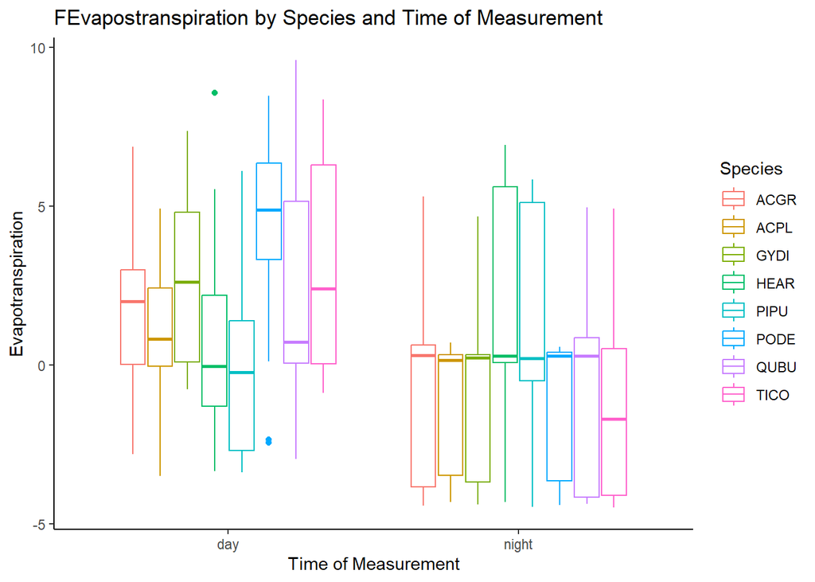

```r
#Evapostranspiration boxplots by species and time of measurements
grove_long %>%
  filter(type == "Est_Evapotranspiration") %>%
  ggplot() +
  geom_boxplot(aes(x = meas_time, y = value, color = Species)) +
  theme_classic() +
  labs(
    title = "FEvapostranspiration by Species and Time of Measurement",
    x = "Time of Measurement",
    y = "Evapotranspiration",
    color = "Species"
  )
```

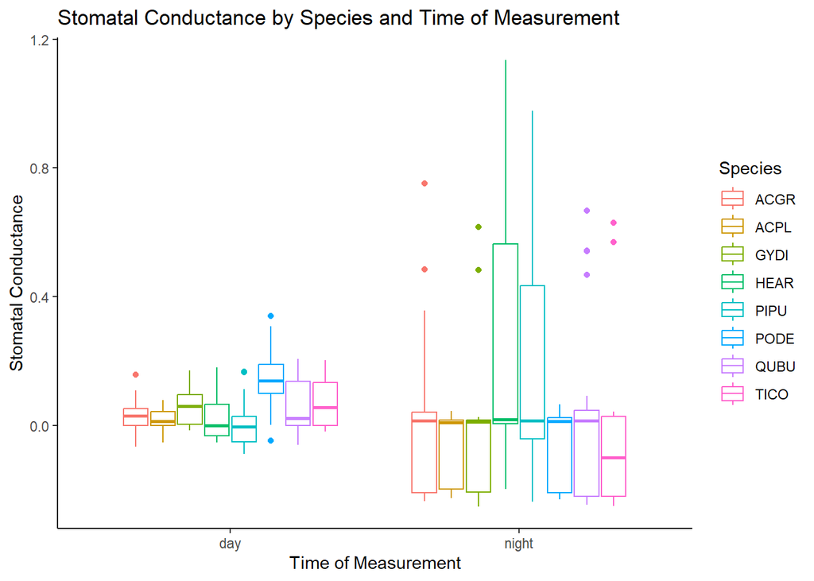

```r
#Stomatal Conductance boxplots by species and time of measurements
grove_long %>%
  filter(type == "Stomatal_Conductance") %>%
  ggplot() +
  geom_boxplot(aes(x = meas_time, y = value, color = Species)) +
  theme_classic() +
  labs(
    title = "Stomatal Conductance by Species and Time of Measurement",
    x = "Time of Measurement",
    y = "Stomatal Conductance",
    color = "Species"
  )
```

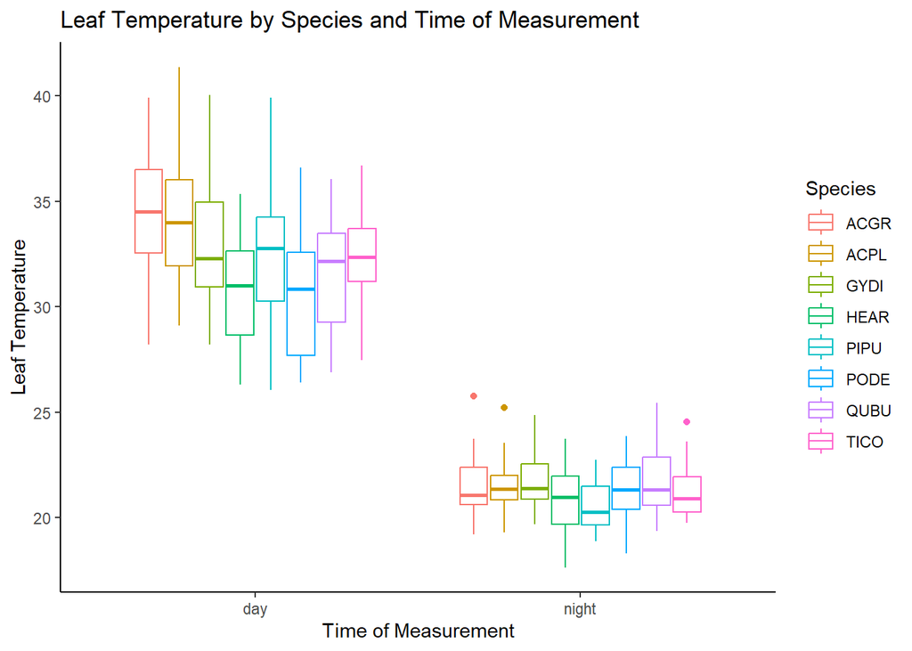

```r
#Leaf Temperature relationships by species and time of measurements
grove_long %>%
  filter(type == "Leaf_Temperature") %>%
  ggplot() +
  geom_boxplot(aes(x = meas_time, y = value, color = Species)) +
  theme_classic() +
  labs(
    title = "Leaf Temperature by Species and Time of Measurement",
    x = "Time of Measurement",
    y = "Leaf Temperature",
    color = "Species"
  )
```

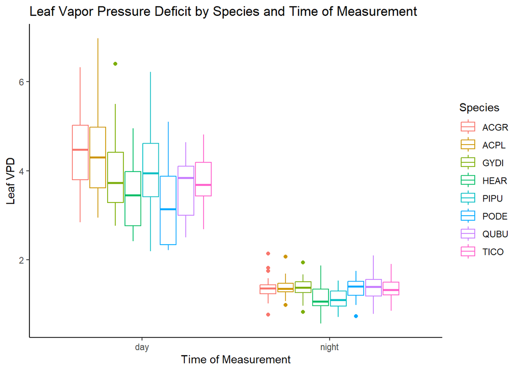

```r
#Leaf Vapor Pressure Deficit relationships by species and time of measurements
grove_long %>%
  filter(type == "Leaf_VPD") %>%
  ggplot() +
  geom_boxplot(aes(x = meas_time, y = value, color = Species)) +
  theme_classic() +
  labs(
    title = "Leaf Vapor Pressure Deficit by Species and Time of Measurement",
    x = "Time of Measurement",
    y = "Leaf VPD",
    color = "Species"
  )
```

## Conclusion

These five figures capture initial exploration of the range of variation of these physiological traits in relation to the eight considered urban tree species.